# Replication of ‘Beyond faces and expertise’ by Zhao, Bülthoff and Bülthoff (2016, Psychological Science)

Dawn Finzi (dfinzi@stanford.edu)

November 26, 2017

## Introduction

In their 2016 Psychological Science paper, Zhao, Bülthoff and Bülthoff showed that nonface objects, specifically line patterns with salient Gestalt information, can elicit holistic processing, even in the absence of expertise. In this paper, holistic processing was measured by composite tasks, where the dependent variable was response sensitivity (d’) and a significant interaction between congruency and alignment in the line composite task (driven by a much larger congruency effectin the aligned conditions than in the misaligned conditions) was taken as evidence of holistic processing for the line pattern stimuli. We aim to replicate Experiment 1a of this paper, where participants are presented with a line composite task and a face composite task in a single session. In that experiment, the authors found evidence for holistic processing of both stimuli types (line and face).

## Methods

### Power Analysis

The effect we are attempting to replicate is the interaction between congruency and alignment in the line pattern task (ηp2 = .52). This original experiment had 22 participants, giving 99.9% a posteriori power with an alpha level of 0.05. A post-hoc power analysis given this effect size and alpha level determines that we would need 8 participants for 80% power, 8 participants for 90% power, and 10 participants for 95% power. Power calculations were run in G*power with the ‘Options’ changed so that the effect size specification was set ‘as in SPSS’.

### Planned Sample

Given the large effect size and relatively small original sample size, we planned to use the same sample size as the original authors (N = 22). However, for reasons of cost, we then reduced from original sample size of 22 to sample size of 15. We plan to use an overall > 55% accuracy cutoff for excluding participants.

### Materials

The materials in the original article were as follows:

> “Composite faces. Face stimuli were created from 20 Caucasian faces (10 males, 10 females; gray-scale images) in the face database of the Max Planck Institute for Biological Cybernetics (Blanz & Vetter, 1999; Troje & Bülthoff, 1996). Twenty face pairs were formed by using each face as a target face once and as a gender-matched paired face once. Each pair was a unique combination of two faces (i.e., any two pairs differed in at least one face). Each face image was cut into a top part and a bottom part (each 270 × 135 pixels). Within the pairs, tops and bottoms were combined to create composite faces (Fig. 1a). For each of the 20 pairs of faces, 8 pairs of composite faces were created following the design illustrated in Figure 1c. Thus, there were 160 pairs of composite faces in total. A 1-pixel black line was added to each composite face to clearly separate the top and bottom parts. Stimuli used for practice trials were created using the same method with additional faces from the database.”

> “Composite patterns. Twenty pairs of line patterns were created; within each pair, one pattern served as the target (Fig. 1b). Each line-pattern stimulus was cut into a top part and a bottom part (each 270 × 135 pixels). Within each pair of line patterns, both the two top parts and the two bottom parts differed from each other, but they could be swapped without disrupting the Gestalt information connecting the top and bottom parts (i.e., connected- ness, closure, and continuity between lines). Aligning the top part of one line pattern with the bottom part of the paired line pattern formed a new line pattern, changing the appearance of the top part (i.e., emergent features were exhibited; Fig. 1b). The composite-pattern stimuli were created using the same method as for the faces. For each of the 20 pairs of line patterns, we created 8 pairs of composite patterns following the design illustrated in Figure 1c, so there were 160 pairs of test stimuli in total. Stimuli used for practice trials were created the same way with additional pairs of line patterns (see Fig. S1 in the Supplemental Material for all line-pattern stimuli).”

For the replication we obtained the line patterns used from the authors, so those stimuli were identical to the original study. However, due to copyright issues, we were not able to obtain the original face stimuli. Instead, we used the face stimuli available from the Rossion lab (Rossion, 2013). However, there were only enough stimuli for 10 pairs of face pairs, so each pair was repeated to create the original number of stimuli.

### Procedure

The original procedure was as follows:

> “Participants performed two composite tasks, one with faces and one with line patterns (order counter- balanced across participants). On each trial, we presented 1 of the 160 pairs of faces or line patterns sequentially with an intervening mask (Figs. 1a and 1b). The target face or line pattern was always presented as the first stimulus. Participants made a same/different judgment about the top parts of the two faces or line patterns. Trials were presented in random order in each task, with an intertrial interval of 1 s (blank screen). Participants were instructed to attend to the top parts only and to ignore the bottom parts. For each task, participants completed eight practice trials before the experimental trials.”

> “We used a complete design of the composite task to measure holistic processing (Richler, Cheung, & Gauthier, 2011). With this design (Fig. 1c), the first stimulus in a trial (i.e., the target face or line pattern) was always aligned. The second was either aligned (aligned condition) or misaligned (misaligned condition). For misaligned faces and line patterns, we shifted the top part to the right and the bottom part to the left by 33 pixels each. The top parts of the two stimuli (i.e., targets) in a trial were either the same (same condition) or different from each other (different condition). Finally, the irrelevant bottom parts were also manipulated. In the congruent condition, the bottom parts were the same in the same condition and were different in the different condition. In the incongruent condition, they were different in the same condition and were the same in the different condition. This design yielded 160 trials per stimulus type (2 alignment conditions × 2 congruency conditions × 2 same/different conditions × 20 exemplars of target stimuli).”

The replication procedure is the same with two exceptions: 1) The order of the tasks is not counterbalanced across participants. The line task is always presented first in order to avoid biasing participants towards using holistic processing techniques as they would with faces. 2) There are only practice trials for the line pattern task not the face task. This is because we have so few face stimuli in comparison to the original experiment. **Note: should I change this and add practice trials for Pilot B?**

The online experiment can be accessed [here](http://stanford.edu/~dfinzi/Zhao_et_al_2016_replication/experiment.html).

### Analysis Plan

1. Exclude any subjects who scored less than 55% accuracy overall
2. Calculate response sensitivity (d’) using hit rates and false alarms for all conditions separately (alignment x congruency x task)
3. Run a 2 (alignment) x 2 (congruency) x 2 (task) repeated measures ANOVA
4. Run separate analyses for each task (line and face tasks). Run a 2 (alignment) x 2 (congruency) repeated measures ANOVA for each task and if there is a significant interaction, run post-hoc comparisons testing the effect of congruency in the aligned and misaligned conditions.

### Differences from Original Study

- We are using a sample size of 15 instead of 22. This should still provide 99% power.
- The face stimuli used are different. The stimuli we used instead have been shown to consistently yield face composite effects so this is not anticipated to make a difference.
- We do not have practice trials for the face composite task due to the lower number of available face stimuli.
- We are not counterbalancing the tasks.
- We are conducting the experiment on Mechanical Turk, not in the lab. Note, however, that the composite face effect has been consistently shown with these presentation times using samples from Mechanical Turk (Susilo, Rezlescu & Duchaine 2013).

## Results

### Data preparation

Data preparation following the analysis plan.

```r
###Data Preparation

####Load Relevant Libraries and Functions

rm(list=ls())
library(tidyverse)
library(jsonlite)
```

```r
library(ez)
library(lsr)

####Import data
path <- "/Users/dfinzi/Desktop/Zhao2016/exp/"
files <- dir(paste0(path,"sandbox-results/"),
             pattern = "*.json")
d.raw <- data.frame()

for (f in files) {
  jf <- paste0(path, "sandbox-results/",f)
  jd <- jsonlite::fromJSON(paste(readLines(jf)), flatten=TRUE)

  worker_id <- jd$WorkerId
  trial_id <- jd$answers$data$trial_id
  trial_index <- jd$answer$data$trial_index
  correct <- jd$answer$data$correct
  alignment <- jd$answer$data$alignment
  congruency <- jd$answer$data$congruency
  response <- jd$answer$data$response
  rt <- jd$answer$data$rt

  id <- cbind(trial_id,trial_index,correct,alignment,congruency,response,rt)
  sub_data <- data.frame(id, worker_id)

  d.raw <- rbind(d.raw,sub_data)
}
# Number of participants
length(unique(d.raw$worker_id))
```

```
## [1] 2
```

```r
#### Data exclusion / filtering
row.has.na <- apply(d.raw, 1, function(x){any(is.na(x))})
d <- d.raw[!row.has.na,] %>%
  mutate(trial_id = ifelse(trial_id == "response_line","line", "face")) %>%
  mutate(correct = ifelse(correct == "TRUE", 1, 0)) %>%
  mutate(answer = ifelse((response=="same"&correct==1)|
                           (response=="different"&correct==0),"same","different"))

# recast variables (imported as lists)
d$rt <- as.numeric(d$rt)
d$trial_index <- as.numeric(d$trial_index)
d$trial_id <- as.factor(d$trial_id)
d$alignment <- as.character(d$alignment)
d$congruency <- as.character(d$congruency)
d$response <- as.character(d$response)

# view to make sure everything is normal
head(d)
```

```
##   trial_id trial_index correct  alignment  congruency  response   rt
## 1     line          38       0 misaligned incongruent different    7
## 2     line          42       1 misaligned incongruent      same 1105
## 3     line          46       1    aligned incongruent      same  288
## 4     line          50       1    aligned incongruent      same   33
## 5     line          54       1 misaligned   congruent different  853
## 6     line          58       1    aligned   congruent      same  290
##        worker_id    answer
## 1 A1JAWSGI1SW8BX      same
## 2 A1JAWSGI1SW8BX      same
## 3 A1JAWSGI1SW8BX      same
## 4 A1JAWSGI1SW8BX      same
## 5 A1JAWSGI1SW8BX different
## 6 A1JAWSGI1SW8BX      same
```

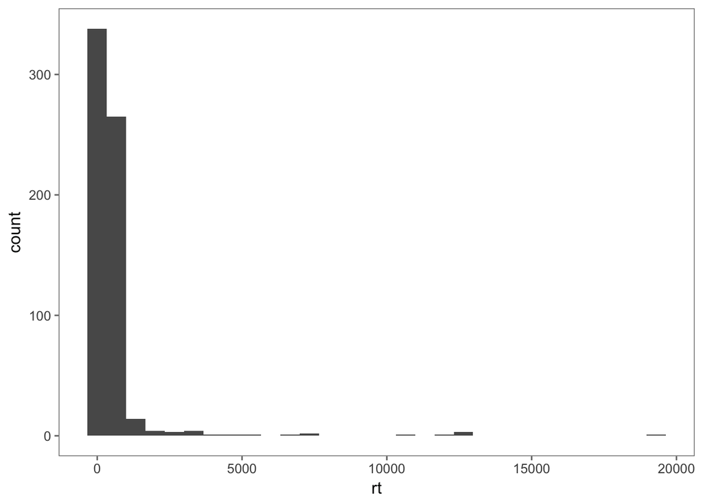

```r
d %>% ggplot(aes(x=rt)) +
  geom_histogram() +
  ggthemes::theme_few()
```

```r
d %>%
  group_by(worker_id) %>%
  summarize (avg = mean(correct))
```

```
## # A tibble: 2 x 2
##        worker_id      avg
##           <fctr>    <dbl>
## 1 A1JAWSGI1SW8BX 0.731250
## 2 A1Z2X2TVQGJ14Y 0.853125
```

```r
#### Prepare data for analysis - create columns etc.

d.tidy <- d %>%
  gather(condition, value, alignment, congruency)
```

### Confirmatory analysis

The analyses as specified in the analysis plan.

```r
## calculate hit rates, false alarms and d' by condition and task
# account for potential hit rates of 1 or false alarm rates of 0
d.results <- d %>%
  group_by(worker_id,trial_id,alignment,congruency) %>%
  summarize(avg = mean(correct),
            false_alarm = sum(response=="same"&answer=="different")/sum(response=="same"),
            hit_rate = sum(response=="different"&answer=="different")/sum(response=="different"),
            max_fa = sum(response=="same"),
            max_hr = sum(response=="different")) %>%
  ungroup() %>%
  mutate(false_alarm = ifelse(false_alarm == 0, 1/(2*max_fa), false_alarm)) %>%
  mutate(hit_rate = ifelse(hit_rate == 1, 1-1/(2*max_hr), hit_rate)) %>%
  group_by(worker_id,trial_id,alignment,congruency) %>%
  mutate(d_prime = qnorm(hit_rate)-qnorm(false_alarm))

## 2 (task) x 2 (congruency) x 2 (alignment) repeated measures ANOVA
overall_anova <- ezANOVA(data = d.results,
                   dv = d_prime,
                   wid = worker_id,
                   within = .(trial_id,congruency,alignment),
                   detailed = T,
                   return_aov = T)
overall_anova$ANOVA
```

```
##                          Effect DFn DFd         SSn        SSd          F
## 1                   (Intercept)   1   1 57.56975609 2.06923051 27.8218188
## 2                      trial_id   1   1  2.41092820 0.30929651  7.7948768
## 3                    congruency   1   1  1.92713052 0.04664721 41.3128784
## 4                     alignment   1   1  0.99133070 0.02216973 44.7155061
## 5           trial_id:congruency   1   1  0.07664470 0.05476239  1.3995863
## 6            trial_id:alignment   1   1  0.02945762 0.26311849  0.1119557
## 7          congruency:alignment   1   1  0.05325439 0.20411372  0.2609055
## 8 trial_id:congruency:alignment   1   1  0.12795014 0.05040512  2.5384354
##            p p<.05         ges
## 1 0.11927883       0.950160610
## 2 0.21895843       0.443946578
## 3 0.09825836       0.389565298
## 4 0.09450277       0.247148420
## 5 0.44674600       0.024752934
## 6 0.79444300       0.009660766
## 7 0.69936169       0.017329782
## 8 0.35682669       0.040648853
```

```r
## individual 2 (congruency) x 2 (alignment) rm ANOVA for the line task
d.line <- d.results %>%
  filter(trial_id == "line")

line_anova <- ezANOVA(data = d.line,
                   dv = d_prime,
                   wid = worker_id,
                   within = .(congruency,alignment),
                   detailed = T,
                   return_aov = T)
line_anova$ANOVA
```

```
##                 Effect DFn DFd          SSn          SSd            F
## 1          (Intercept)   1   1 41.771536823 0.3892598998 1.073101e+02
## 2           congruency   1   1  1.386210824 0.0001626127 8.524618e+03
## 3            alignment   1   1  0.681280795 0.0662682914 1.028065e+01
## 4 congruency:alignment   1   1  0.008055876 0.2286910594 3.522602e-02
##             p p<.05        ges
## 1 0.061265519       0.98388018
## 2 0.006894864     * 0.66947538
## 3 0.192463798       0.49886463
## 4 0.881889467       0.01163408
```

```r
# post hoc t tests
num_tests_line = 2 #2 post hoc t tests (1 for aligned and 1 for misaligned)

# test effect of congruency in aligned condition
# (Note to self: there has got to be a better way to do this!)
d.line.aligned <- d.line %>%
  filter(alignment == "aligned") %>%
  dplyr::select(worker_id, congruency, d_prime)
x1 <- d.line.aligned %>%
  filter(congruency == "congruent")

x2 <- d.line.aligned %>%
  filter(congruency == "incongruent")

t.line.aligned <- t.test(x1$d_prime, x2$d_prime, paired = T)
t.line.aligned$p.value <- t.line.aligned$p.value*num_tests_line
t.line.aligned
```

```
##
##  Paired t-test
##
## data:  x1$d_prime and x2$d_prime
## t = 2.3366, df = 1, p-value = 0.5149
## alternative hypothesis: true difference in means is not equal to 0
## 95 percent confidence interval:
##  -3.412970  4.951097
## sample estimates:
## mean of the differences
##               0.7690635
```

```r
# test effect of congruency in misaligned condition
d.line.misaligned <- d.line %>%
  filter(alignment == "misaligned") %>%
  dplyr::select(worker_id, congruency, d_prime)
x1 <- d.line.misaligned %>%
  filter(congruency == "congruent")

x2 <- d.line.misaligned %>%
  filter(congruency == "incongruent")

t.line.misaligned <- t.test(x1$d_prime, x2$d_prime, paired = T)
t.line.misaligned$p.value <- t.line.misaligned$p.value*num_tests_line
t.line.misaligned
```

```
##
##  Paired t-test
##
## data:  x1$d_prime and x2$d_prime
## t = 2.5809, df = 1, p-value = 0.4707
## alternative hypothesis: true difference in means is not equal to 0
## 95 percent confidence interval:
##  -3.515181  5.307173
## sample estimates:
## mean of the differences
##               0.8959956
```

```r
## individual 2 (congruency) x 2 (alignment) rm ANOVA for the face task
d.face <- d.results %>%
  filter(trial_id == "face")

face_anova <- ezANOVA(data = d.face,
                   dv = d_prime,
                   wid = worker_id,
                   within = .(congruency,alignment),
                   detailed = T,
                   return_aov = T)
face_anova$ANOVA
```

```
##                 Effect DFn DFd        SSn        SSd        F         p
## 1          (Intercept)   1   1 18.2091475 1.98926711 9.153697 0.2032212
## 2           congruency   1   1  0.6175644 0.10124699 6.099583 0.2449236
## 3            alignment   1   1  0.3395075 0.21901993 1.550122 0.4307890
## 4 congruency:alignment   1   1  0.1731487 0.02582778 6.703969 0.2346392
##   p<.05        ges
## 1       0.88632672
## 2       0.20913641
## 3       0.12692490
## 4       0.06902449
```

```r
# post hoc t tests
num_tests_face = 2 #2 post hoc t tests (1 for aligned and 1 for misaligned)

# test effect of congruency in aligned condition
d.face.aligned <- d.face %>%
  filter(alignment == "aligned") %>%
  dplyr::select(worker_id, congruency, d_prime)
x1 <- d.face.aligned %>%
  filter(congruency == "congruent")

x2 <- d.face.aligned %>%
  filter(congruency == "incongruent")

t.face.aligned <- t.test(x1$d_prime, x2$d_prime, paired = T)
t.face.aligned$p.value <- t.face.aligned$p.value*num_tests_face
t.face.aligned
```

```
##
##  Paired t-test
##
## data:  x1$d_prime and x2$d_prime
## t = 2.5098, df = 1, p-value = 0.4828
## alternative hypothesis: true difference in means is not equal to 0
## 95 percent confidence interval:
##  -3.452861  5.152695
## sample estimates:
## mean of the differences
##               0.8499169
```

```r
# test effect of congruency in misaligned condition
d.face.misaligned <- d.face %>%
  filter(alignment == "misaligned") %>%
  dplyr::select(worker_id, congruency, d_prime)
x1 <- d.face.misaligned %>%
  filter(congruency == "congruent")

x2 <- d.face.misaligned %>%
  filter(congruency == "incongruent")

t.face.misaligned <- t.test(x1$d_prime, x2$d_prime, paired = T)
t.face.misaligned$p.value <- t.face.misaligned$p.value*num_tests_face
t.face.misaligned
```

```
##
##  Paired t-test
##
## data:  x1$d_prime and x2$d_prime
## t = 2.3478, df = 1, p-value = 0.5127
## alternative hypothesis: true difference in means is not equal to 0
## 95 percent confidence interval:
##  -1.153483  1.676376
## sample estimates:
## mean of the differences
##               0.2614466
```

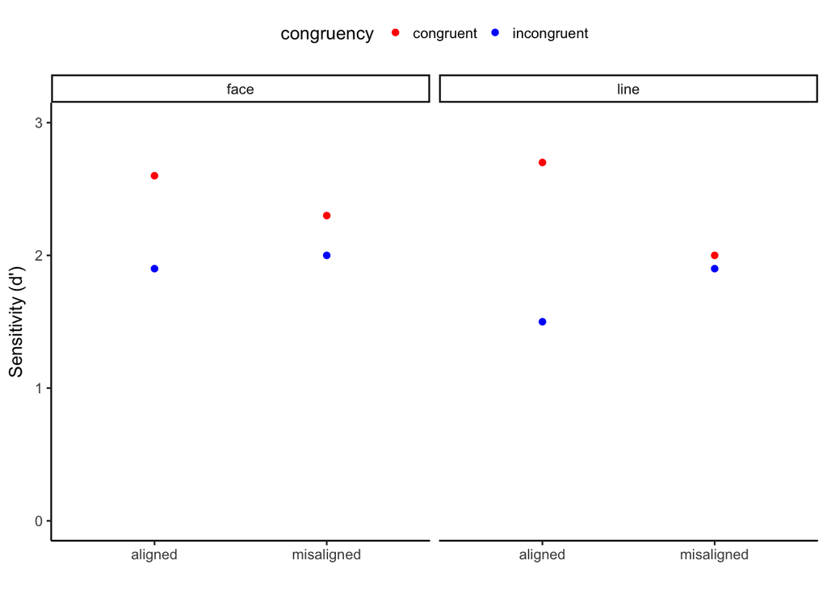

```r
## Reproduce original graph
# use data frame structure of d.results
orig <- d.results[1:8,]
orig <- orig %>%
  ungroup() %>%
  select(trial_id,alignment,congruency,d_prime)
# replace d prime values with values from paper - exact values were not reported and had to be approximated from the original figure
orig$d_prime <- c(2.6,1.9,2.3,2,2.7,1.5,2,1.9)
# plot face and line data
orig %>%
  ggplot(aes(x= alignment, y = d_prime)) +
  facet_grid(.~ trial_id) +
  geom_point(aes(col=congruency))+
  ylim(0,3) + ylab("Sensitivity (d')") + xlab("") +
  scale_color_manual(values=c("red", "blue")) +
  theme_classic() +
  theme(legend.position = "top")
```

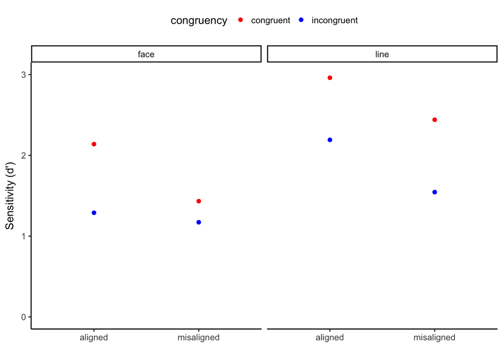

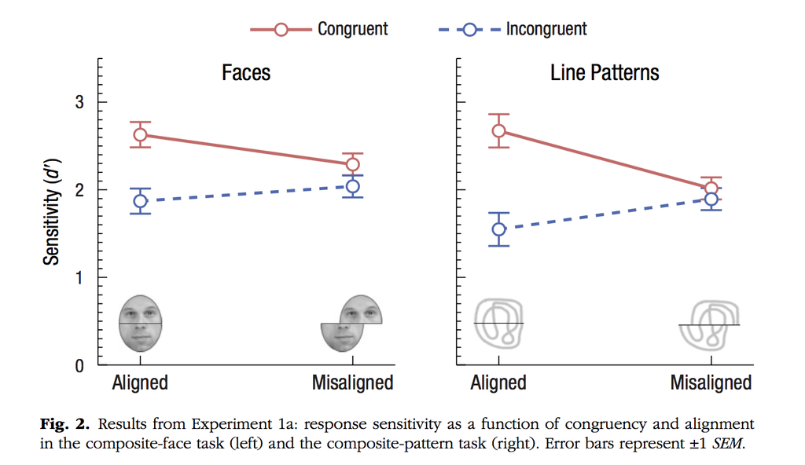

```r
## Plot the replication data in the same format
d.plot <- d.results %>%
  ungroup() %>%
  group_by(trial_id,alignment,congruency) %>%
  summarize(avg = mean(d_prime))
d.plot %>%
  ggplot(aes(x= alignment, y = avg)) +
  facet_grid(.~ trial_id) +
  geom_point(aes(col=congruency))+
  ylim(0,3) + ylab("Sensitivity (d')") + xlab("") +
  scale_color_manual(values=c("red", "blue")) +
  theme_classic() +
  theme(legend.position = "top")
```

## Discussion

### Summary of Replication Attempt